# Online Shoppers Intention

Technical Report

Pedro López-Escribano Zamora

1/12/2020

# Proyect Description

## General objective

- Analyze the behavior and purchases of users in an online store and determine which characteristics have more weight to make a purchase or not.

## Specific objective

- Create a model that allows estimating the probability a user has to make a purchase, in this way commercial decisions can be made, such as offering specific offers or recommending a series of products similar to those that the user is looking for.

## Data Description

- The dataset consists of 10 numerical and 8 categorical attributes, with 12330 observation (users).
- The **‘Revenue’** attribute is a Boolean field, where TRUE means that the user bought an item. This attribute is what we want to predict with Machine Learning models.
- **“Administrative”, “Administrative Duration”, “Informational”, “Informational Duration”, “Product Related” and “Product Related Duration”** represent the number of different types of pages visited by the visitor in that session and total time spent in each of these page categories. The values of these features are derived from the URL information of the pages visited by the user and updated in real time when a user takes an action, e.g. moving from one page to another.
- The **“Bounce Rate”**, **“Exit Rate”** and **“Page Value”** features represent the metrics measured by “Google Analytics” for each page in the e-commerce site.
- The value of **“Bounce Rate”** feature for a web page refers to the percentage of visitors who enter the site from that page and then leave (“bounce”) without triggering any other requests to the analytics server during that session.
- The value of **“Exit Rate”** feature for a specific web page is calculated as for all pageviews to the page, the percentage that were the last in the session.
- The **“Page Value”** feature represents the average value for a web page that a user visited before completing an e-commerce transaction.
- The **“Special Day”** feature indicates the closeness of the site visiting time to a specific special day (e.g. Mother’s Day, Valentine’s Day) in which the sessions are more likely to be finalized with transaction. The value of this attribute is determined by considering the dynamics of e-commerce such as the duration between the order date and delivery date. For example, for Valentina’s day, this value takes a nonzero value between February 2 and February 12, zero before and after this date unless it is close to another special day, and its maximum value of 1 on February 8.
- The dataset also includes **operating system, browser, region, traffic type, visitor type** as returning or new visitor, a Boolean value indicating whether the date of the visit is **weekend**, and **month** of the year, we have ten months, January and April are missing, we don’t know if February and December are complete.

## Librarys

```r
library(ellipsis)
library(tidyverse)
library(broom)
library(purrr)
library(dummies)
library(scales)
library(GGally)
library(corrplot)
library(gridExtra)
library(grid)
library(h2o)
library(xgboost)
library(ggpubr)
library(caret)
library(Metrics)
library(e1071)
library(Ckmeans.1d.dp)
library(usethis)
library(glue)
library(devtools)
library(lares)         #install_github("laresbernardo/lares", dependencies = TRUE)
library(modelplotr)   #install_github("modelplot/modelplotr")
```

# Load data and check

```r
data <- read.csv("raw_data/online_shoppers_intention.csv")
str(data)
```

```
## 'data.frame':    12330 obs. of  18 variables:
##  $ Administrative         : int  0 0 0 0 0 0 0 1 0 0 ...
##  $ Administrative_Duration: num  0 0 -1 0 0 0 -1 -1 0 0 ...
##  $ Informational          : int  0 0 0 0 0 0 0 0 0 0 ...
##  $ Informational_Duration : num  0 0 -1 0 0 0 -1 -1 0 0 ...
##  $ ProductRelated         : int  1 2 1 2 10 19 1 1 2 3 ...
##  $ ProductRelated_Duration: num  0 64 -1 2.67 627.5 ...
##  $ BounceRates            : num  0.2 0 0.2 0.05 0.02 ...
##  $ ExitRates              : num  0.2 0.1 0.2 0.14 0.05 ...
##  $ PageValues             : num  0 0 0 0 0 0 0 0 0 0 ...
##  $ SpecialDay             : num  0 0 0 0 0 0 0.4 0 0.8 0.4 ...
##  $ Month                  : chr  "Feb" "Feb" "Feb" "Feb" ...
##  $ OperatingSystems       : int  1 2 4 3 3 2 2 1 2 2 ...
##  $ Browser                : int  1 2 1 2 3 2 4 2 2 4 ...
##  $ Region                 : int  1 1 9 2 1 1 3 1 2 1 ...
##  $ TrafficType            : int  1 2 3 4 4 3 3 5 3 2 ...
##  $ VisitorType            : chr  "Returning_Visitor" "Returning_Visitor" "Returning_Visitor" "Returning_Visitor" ...
##  $ Weekend                : logi  FALSE FALSE FALSE FALSE TRUE FALSE ...
##  $ Revenue                : logi  FALSE FALSE FALSE FALSE FALSE FALSE ...
```

```r
summary(data)
```

```
##  Administrative   Administrative_Duration Informational
##  Min.   : 0.000   Min.   :  -1.00         Min.   : 0.000
##  1st Qu.: 0.000   1st Qu.:   0.00         1st Qu.: 0.000
##  Median : 1.000   Median :   8.00         Median : 0.000
##  Mean   : 2.318   Mean   :  80.91         Mean   : 0.504
##  3rd Qu.: 4.000   3rd Qu.:  93.50         3rd Qu.: 0.000
##  Max.   :27.000   Max.   :3398.75         Max.   :24.000
##  NA's   :14       NA's   :14              NA's   :14
##  Informational_Duration ProductRelated   ProductRelated_Duration
##  Min.   :  -1.00        Min.   :  0.00   Min.   :   -1.0
##  1st Qu.:   0.00        1st Qu.:  7.00   1st Qu.:  185.0
##  Median :   0.00        Median : 18.00   Median :  599.8
##  Mean   :  34.51        Mean   : 31.76   Mean   : 1196.0
##  3rd Qu.:   0.00        3rd Qu.: 38.00   3rd Qu.: 1466.5
##  Max.   :2549.38        Max.   :705.00   Max.   :63973.5
##  NA's   :14             NA's   :14       NA's   :14
##   BounceRates         ExitRates         PageValues        SpecialDay
##  Min.   :0.000000   Min.   :0.00000   Min.   :  0.000   Min.   :0.00000
##  1st Qu.:0.000000   1st Qu.:0.01429   1st Qu.:  0.000   1st Qu.:0.00000
##  Median :0.003119   Median :0.02512   Median :  0.000   Median :0.00000
##  Mean   :0.022152   Mean   :0.04300   Mean   :  5.889   Mean   :0.06143
##  3rd Qu.:0.016684   3rd Qu.:0.05000   3rd Qu.:  0.000   3rd Qu.:0.00000
##  Max.   :0.200000   Max.   :0.20000   Max.   :361.764   Max.   :1.00000
##  NA's   :14         NA's   :14
##     Month           OperatingSystems    Browser           Region
##  Length:12330       Min.   :1.000    Min.   : 1.000   Min.   :1.000
##  Class :character   1st Qu.:2.000    1st Qu.: 2.000   1st Qu.:1.000
##  Mode  :character   Median :2.000    Median : 2.000   Median :3.000
##                     Mean   :2.124    Mean   : 2.357   Mean   :3.147
##                     3rd Qu.:3.000    3rd Qu.: 2.000   3rd Qu.:4.000
##                     Max.   :8.000    Max.   :13.000   Max.   :9.000
##
##   TrafficType    VisitorType         Weekend         Revenue
##  Min.   : 1.00   Length:12330       Mode :logical   Mode :logical
##  1st Qu.: 2.00   Class :character   FALSE:9462      FALSE:10422
##  Median : 2.00   Mode  :character   TRUE :2868      TRUE :1908
##  Mean   : 4.07
##  3rd Qu.: 4.00
##  Max.   :20.00
##
```

- With the summary function we can see that **14** rows contain NA’s.

# Clean and transform

- We are going to check the unique values and analyze the NA’s

```r
nuniques <- as.data.frame(sapply(data, function(x) length(unique(x))))
colnames(nuniques) <- "n_unique"
rownames_to_column(nuniques, "Variable")
```

```
##                   Variable n_unique
## 1           Administrative       28
## 2  Administrative_Duration     3337
## 3            Informational       18
## 4   Informational_Duration     1260
## 5           ProductRelated      312
## 6  ProductRelated_Duration     9553
## 7              BounceRates     1873
## 8                ExitRates     4778
## 9               PageValues     2704
## 10              SpecialDay        6
## 11                   Month       10
## 12        OperatingSystems        8
## 13                 Browser       13
## 14                  Region        9
## 15             TrafficType       20
## 16             VisitorType        3
## 17                 Weekend        2
## 18                 Revenue        2
```

```r
data[rowSums(is.na(data)) > 0,]
```

```
##      Administrative Administrative_Duration Informational
## 1066             NA                      NA            NA
## 1133             NA                      NA            NA
## 1134             NA                      NA            NA
## 1135             NA                      NA            NA
## 1136             NA                      NA            NA
## 1137             NA                      NA            NA
## 1474             NA                      NA            NA
## 1475             NA                      NA            NA
## 1476             NA                      NA            NA
## 1477             NA                      NA            NA
## 2038             NA                      NA            NA
## 2039             NA                      NA            NA
## 2040             NA                      NA            NA
## 2754             NA                      NA            NA
```

[output cut: 45 more lines]

- I am going to transform the columns below 18 and above 2 unique values to a categorical type (factor type in R) and convert the month variable into an ordered categorical variable, in order to obtain a good visualization when we graph the data.
- We can see some patterns in the NA values.
  - 14 rows with NA’s in the same columns.
  - All these values belong March.
  - Visitor type “Returning_Visitor”.
  - Revenue “FALSE”.
- These NA’s are probably due to a failure in the data collection, as there are so few I will simply delete them.

```r
for (row in row.names(nuniques)){
    if (nuniques[row,] < 18 & nuniques[row,] > 2)
        data[[ row]] <- factor(data[[ row]])
}
df <- drop_na(data)
df$Month<- fct_relevel(df$Month, c("Feb", "Mar", "May", "June", "Jul", "Aug", "Sep", "Oct", "Nov", "Dec"))
df$Month<- factor(df$Month, ordered = T)
str(df)
```

```
## 'data.frame':    12316 obs. of  18 variables:
##  $ Administrative         : int  0 0 0 0 0 0 0 1 0 0 ...
##  $ Administrative_Duration: num  0 0 -1 0 0 0 -1 -1 0 0 ...
##  $ Informational          : int  0 0 0 0 0 0 0 0 0 0 ...
##  $ Informational_Duration : num  0 0 -1 0 0 0 -1 -1 0 0 ...
##  $ ProductRelated         : int  1 2 1 2 10 19 1 1 2 3 ...
##  $ ProductRelated_Duration: num  0 64 -1 2.67 627.5 ...
##  $ BounceRates            : num  0.2 0 0.2 0.05 0.02 ...
##  $ ExitRates              : num  0.2 0.1 0.2 0.14 0.05 ...
##  $ PageValues             : num  0 0 0 0 0 0 0 0 0 0 ...
##  $ SpecialDay             : Factor w/ 6 levels "0","0.2","0.4",..: 1 1 1 1 1 1 3 1 5 3 ...
##  $ Month                  : Ord.factor w/ 10 levels "Feb"<"Mar"<"May"<..: 1 1 1 1 1 1 1 1 1 1 ...
##  $ OperatingSystems       : Factor w/ 8 levels "1","2","3","4",..: 1 2 4 3 3 2 2 1 2 2 ...
##  $ Browser                : Factor w/ 13 levels "1","2","3","4",..: 1 2 1 2 3 2 4 2 2 4 ...
##  $ Region                 : Factor w/ 9 levels "1","2","3","4",..: 1 1 9 2 1 1 3 1 2 1 ...
##  $ TrafficType            : int  1 2 3 4 4 3 3 5 3 2 ...
##  $ VisitorType            : Factor w/ 3 levels "New_Visitor",..: 3 3 3 3 3 3 3 3 3 3 ...
##  $ Weekend                : logi  FALSE FALSE FALSE FALSE TRUE FALSE ...
##  $ Revenue                : logi  FALSE FALSE FALSE FALSE FALSE FALSE ...
```

# EDA

## Univariate analysis per data type

- I’m going to plot by data type, using one geometry or another depends on this.

### Factor

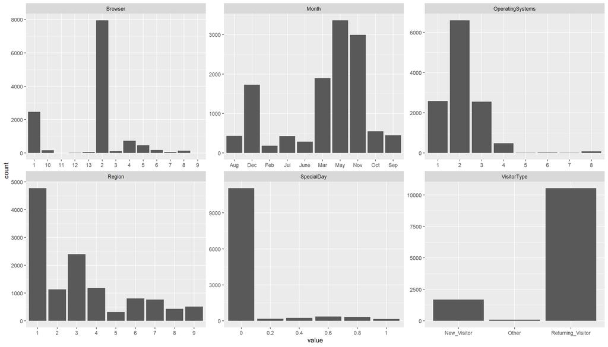

```r
df %>%
select_if(is.factor) %>%
    gather() %>%
    ggplot(aes(x = value)) +
    facet_wrap(~ key, scales = "free") +
    geom_bar()
```

- Proportions of each value

```r
props<- function(var){
  group <- group_by(df, df[[var]]) %>% summarize(n = n()) %>%
  ungroup() %>% mutate(prop = n/sum(n)) %>% select(1,3)
  colnames(group) <- c(var, "prop")
  group
}

for (var in colnames(select_if(df, is.factor))){
  print(props(var))
}
```

```
## # A tibble: 6 x 2
##   SpecialDay   prop
##   <fct>       <dbl>
## 1 0          0.898
## 2 0.2        0.0145
## 3 0.4        0.0197
## 4 0.6        0.0285
## 5 0.8        0.0264
## 6 1          0.0125
## # A tibble: 10 x 2
##    Month   prop
##    <ord>  <dbl>
##  1 Feb   0.0149
##  2 Mar   0.154
##  3 May   0.273
```

[output cut: 52 more lines]

### Boolean

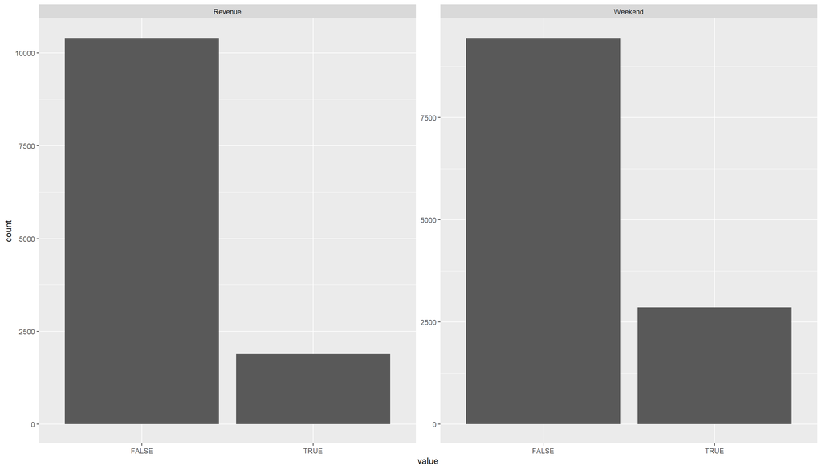

```r
df %>%
select_if(is.logical) %>%
    gather() %>%
    ggplot(aes(x = value)) +
    facet_wrap(~ key, scales = "free") +
    geom_bar()
```

- Proportions of each value

```r
for (var in colnames(select_if(df, is.logical))){
  print(props(var))
}
```

```
## # A tibble: 2 x 2
##   Weekend  prop
##   <lgl>   <dbl>
## 1 FALSE   0.767
## 2 TRUE    0.233
## # A tibble: 2 x 2
##   Revenue  prop
##   <lgl>   <dbl>
## 1 FALSE   0.845
## 2 TRUE    0.155
```

### Numeric

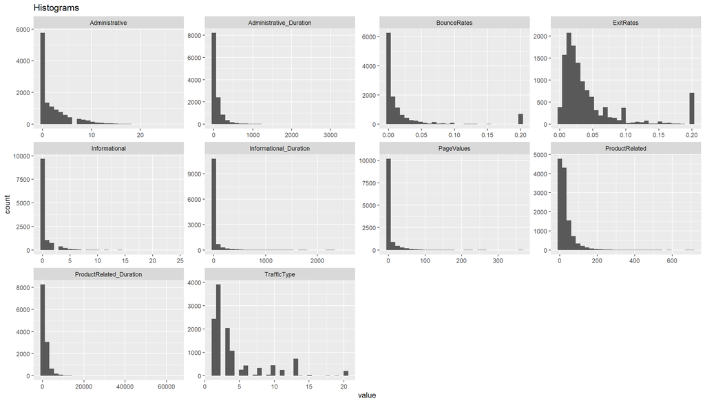

```r
df %>%
    select_if(is.numeric) %>%
    gather() %>%
    ggplot(aes(x = value)) +
        facet_wrap(~ key, scales = "free") +
        geom_histogram() +
            labs(title = "Histograms")
```

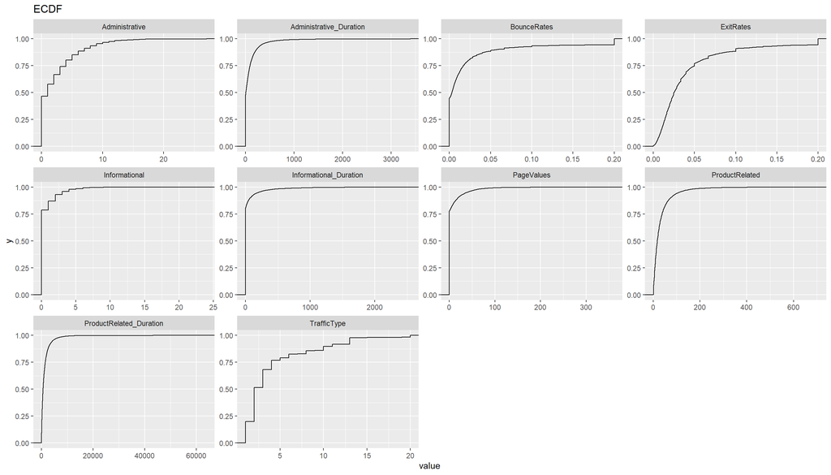

```r
df %>%
    select_if(is.numeric) %>%
    gather() %>%
    ggplot(aes(x = value)) +
        facet_wrap(~ key, scales = "free") +
        stat_ecdf() +
            labs(title = "ECDF")
```

- Most variables have many values at or near 0, in other words, they have positive skewness. We can use the fitdistrplus library to find out which distribution our data best fits. However, this function does not evaluate all possible distributions, but it does give us enough information.

```r
num_vars <- df %>% select_if(is.numeric)

for (var in colnames(num_vars)){
    if (n_distinct(df[[var]]) <= 28){
        print(fitdistrplus::descdist(df[[var]], discrete = T, boot = 500, method = "sample")) #Discrete vars
        print(title(var, outer = T, cex.main = 1, line = -3.5))
    }
    else{
        print(fitdistrplus::descdist(df[[var]], discrete = F, boot = 500, method = "sample")) #Continous vars
        print(title(var, outer = T, cex.main = 1, line = -3.5))
    }
}
```

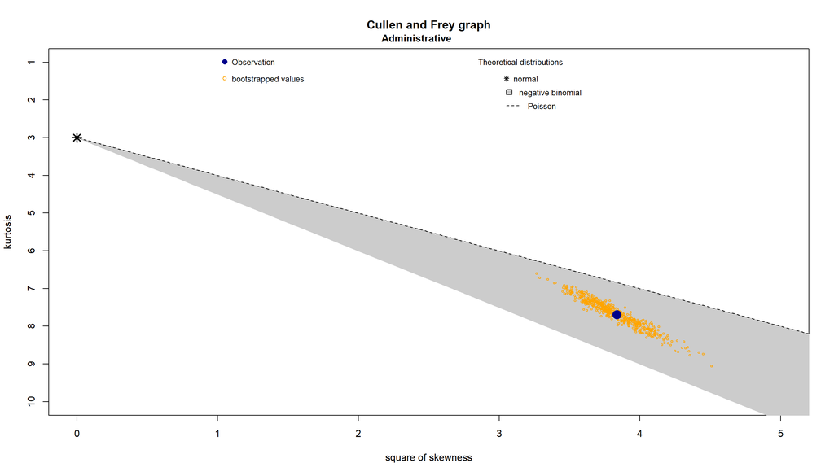

```
## summary statistics
## ------
## min:  0   max:  27
## median:  1
## mean:  2.317798
## sample sd:  3.322619
## sample skewness:  1.958638
## sample kurtosis:  7.692035
## NULL
```

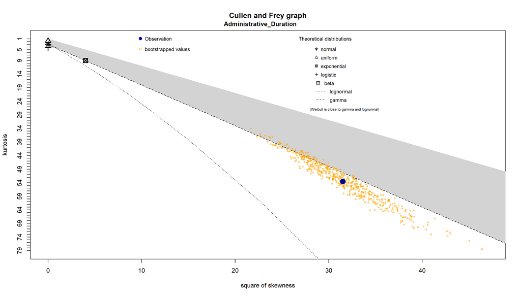

```
## summary statistics
## ------
## min:  -1   max:  3398.75
## median:  8
## mean:  80.90618
## sample sd:  176.8533
## sample skewness:  5.612277
## sample kurtosis:  53.48695
## NULL
```

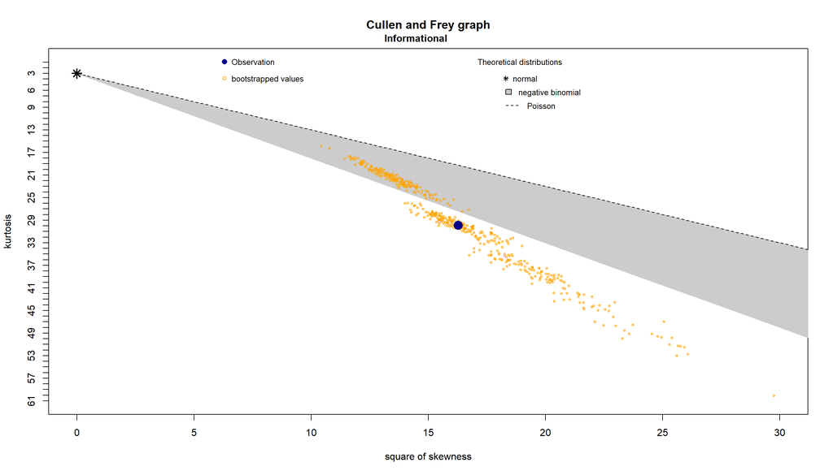

```
## summary statistics
## ------
## min:  0   max:  24
## median:  0
## mean:  0.5039786
## sample sd:  1.27065
## sample skewness:  4.034331
## sample kurtosis:  29.89815
## NULL
```

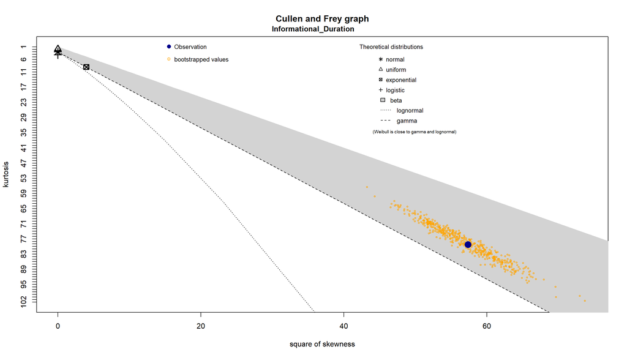

```
## summary statistics
## ------
## min:  -1   max:  2549.375
## median:  0
## mean:  34.50639
## sample sd:  140.8198
## sample skewness:  7.573859
## sample kurtosis:  79.19662
## NULL
```

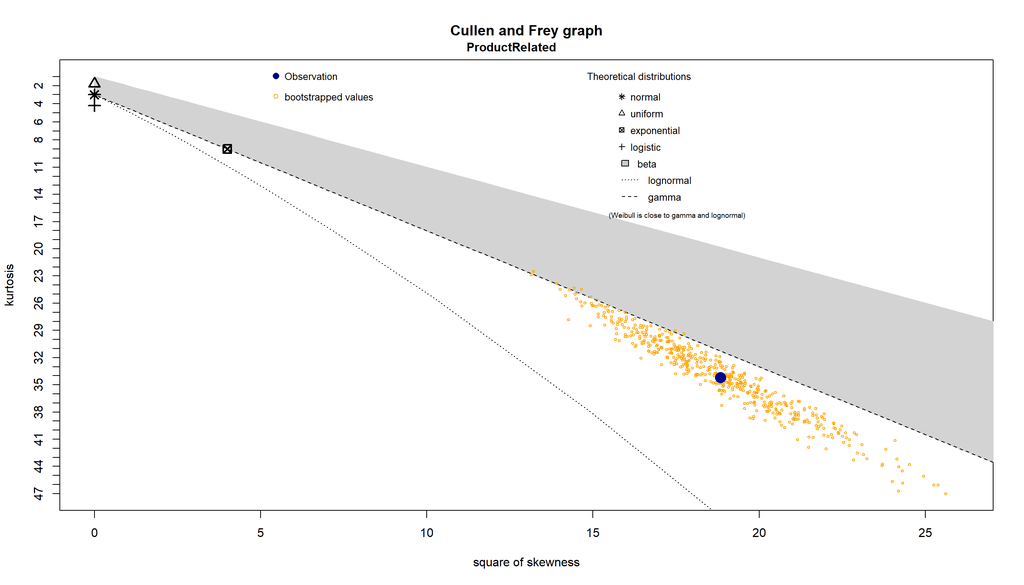

```
## summary statistics
## ------
## min:  0   max:  705
## median:  18
## mean:  31.76388
## sample sd:  44.48853
## sample skewness:  4.339694
## sample kurtosis:  34.17895
## NULL
```

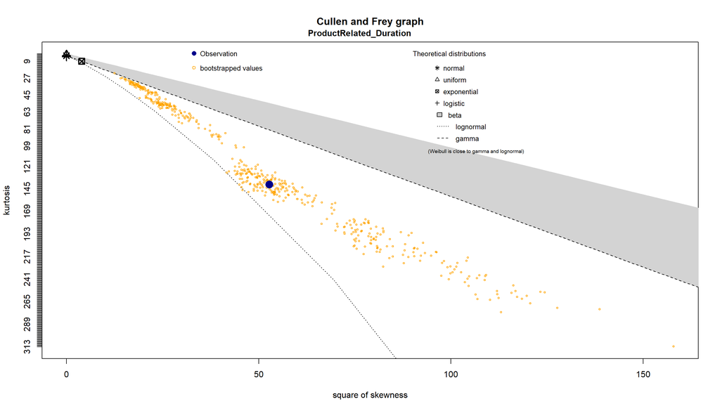

```
## summary statistics
## ------
## min:  -1   max:  63973.52
## median:  599.7662
## mean:  1196.037
## sample sd:  1914.295
## sample skewness:  7.260807
## sample kurtosis:  140.0516
## NULL
```

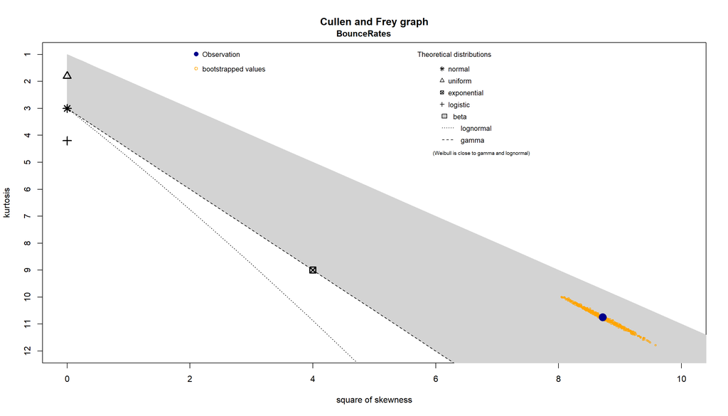

```
## summary statistics
## ------
## min:  0   max:  0.2
## median:  0.003119412
## mean:  0.02215246
## sample sd:  0.04842516
## sample skewness:  2.952107
## sample kurtosis:  10.7507
## NULL
```

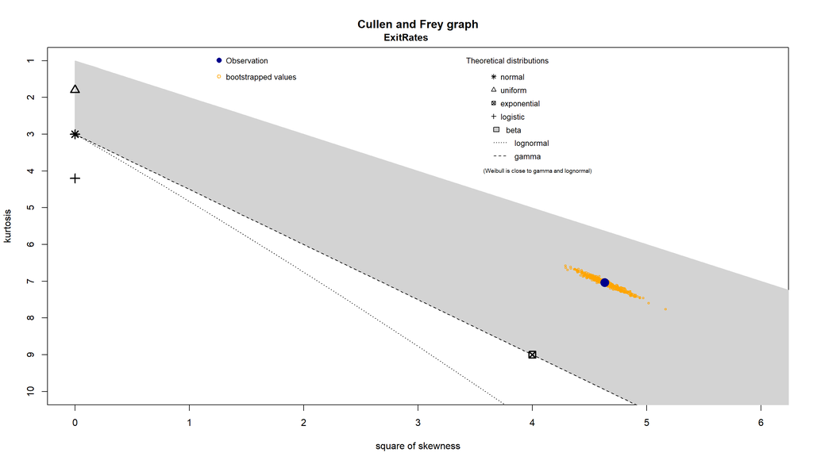

```
## summary statistics
## ------
## min:  0   max:  0.2
## median:  0.02512449
## mean:  0.04300254
## sample sd:  0.04852533
## sample skewness:  2.152491
## sample kurtosis:  7.037883
## NULL
```

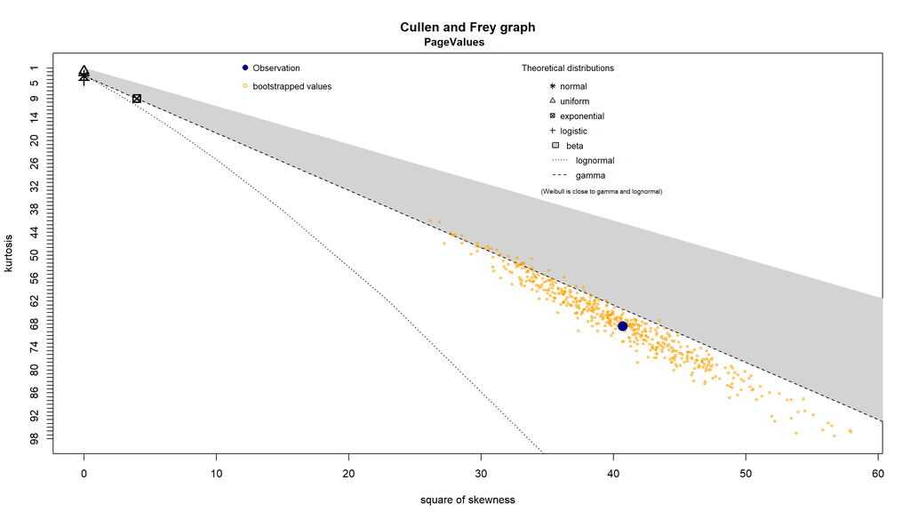

```
## summary statistics
## ------
## min:  0   max:  361.7637
## median:  0
## mean:  5.895952
## sample sd:  18.57717
## sample skewness:  6.378613
## sample kurtosis:  68.53716
## NULL
```

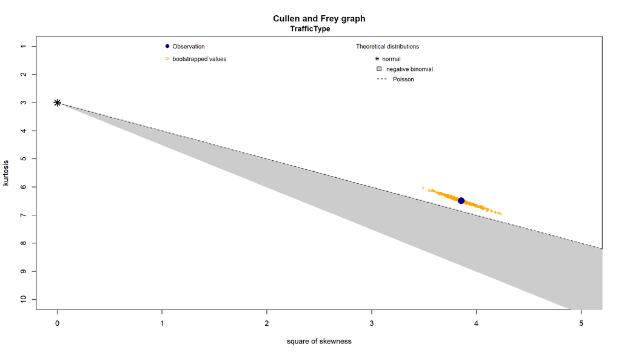

```
## summary statistics
## ------
## min:  1   max:  20
## median:  2
## mean:  4.070477
## sample sd:  4.024434
## sample skewness:  1.962936
## sample kurtosis:  6.48052
## NULL
```

- You can find useful information about the different distributions and parameters to use for Skew distributions to the right on wikipedia https://en.wikipedia.org/wiki/Probability_distribution_fitting

## Bivariate analysis

### Categorical variables

- The variable to predict is binary so I’m going to graph the count of the variable to compare and the proportion in which each value is False or True.

```
## [1] "SpecialDay"
```

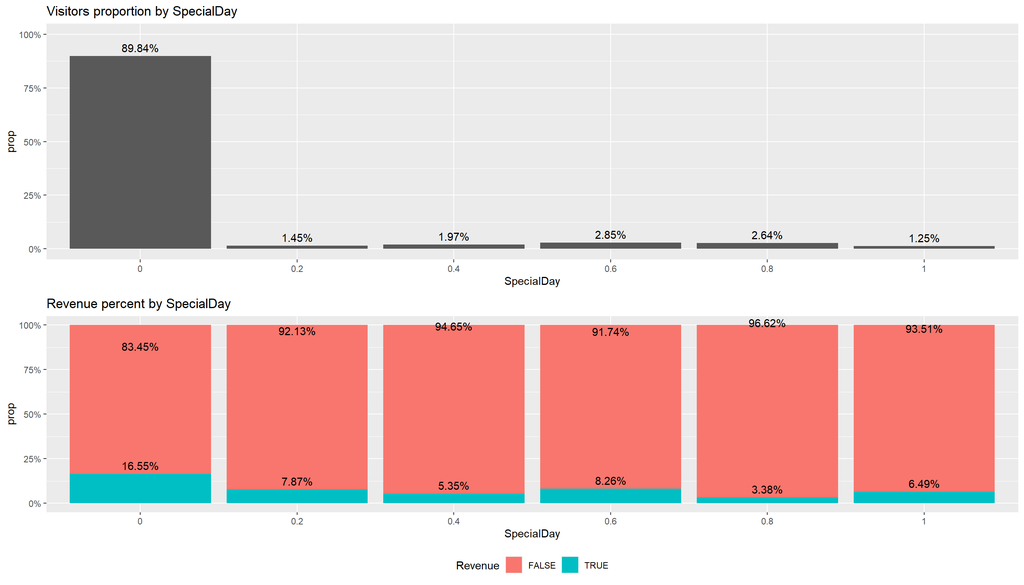

```
## [1] "Month"
```

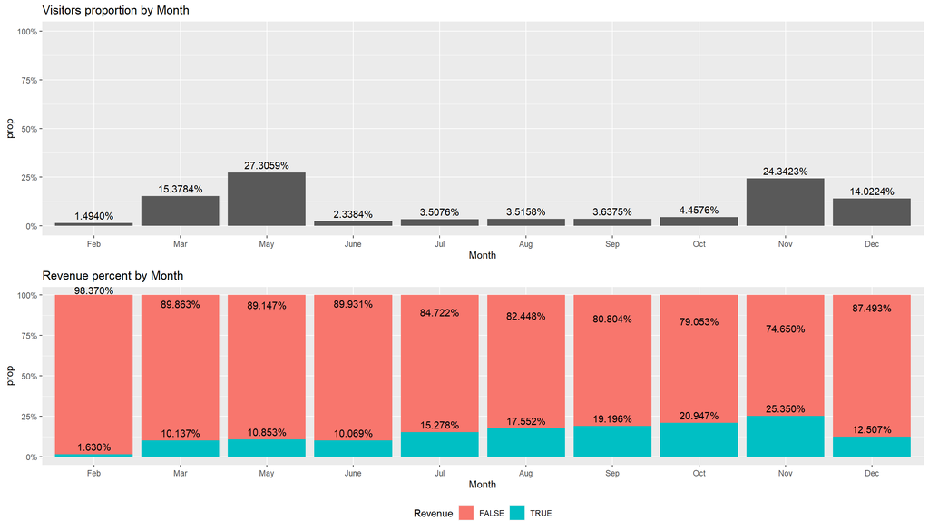

```
## [1] "OperatingSystems"
```

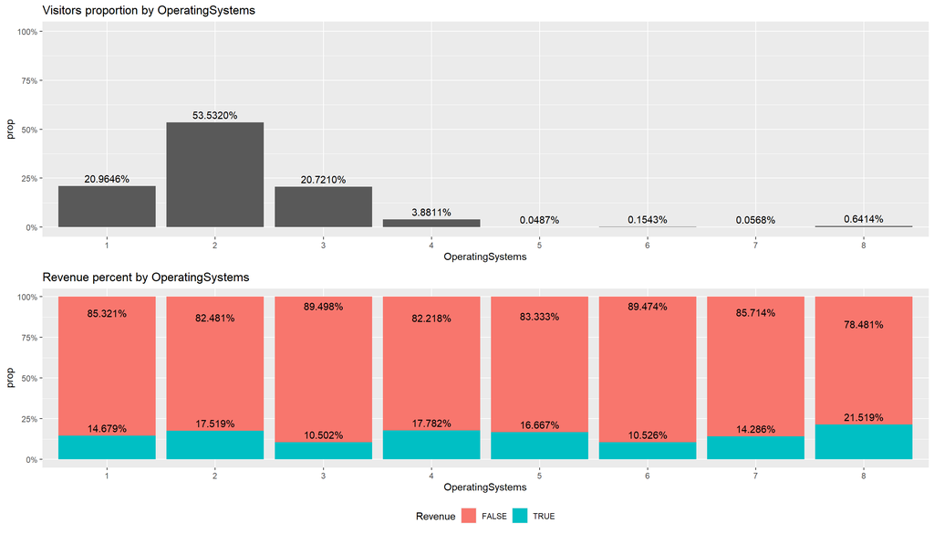

```
## [1] "Browser"
```

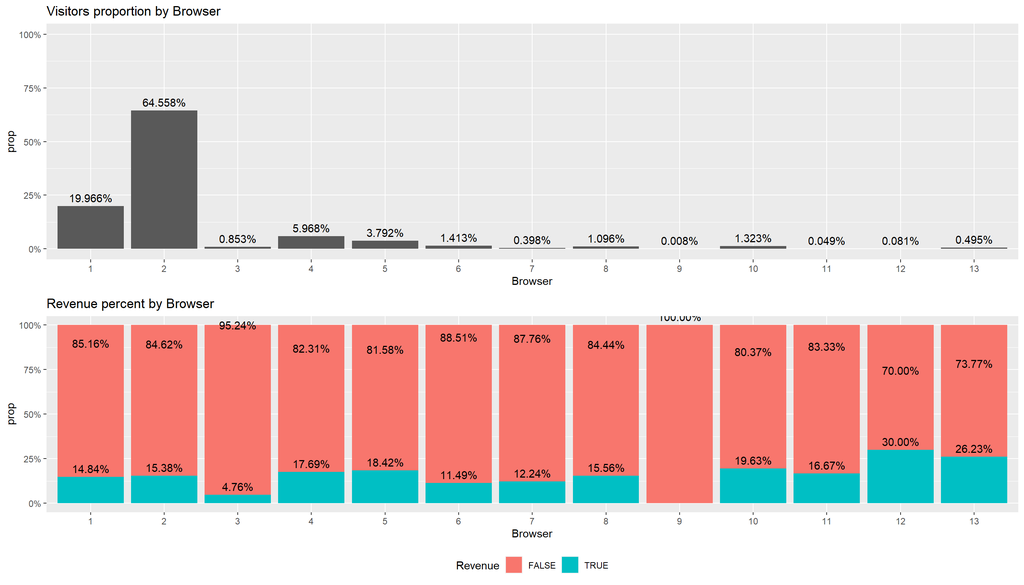

```
## [1] "Region"
```

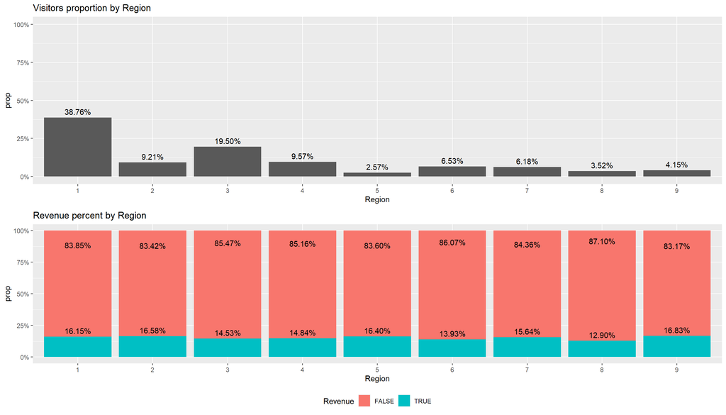

```
## [1] "VisitorType"
```

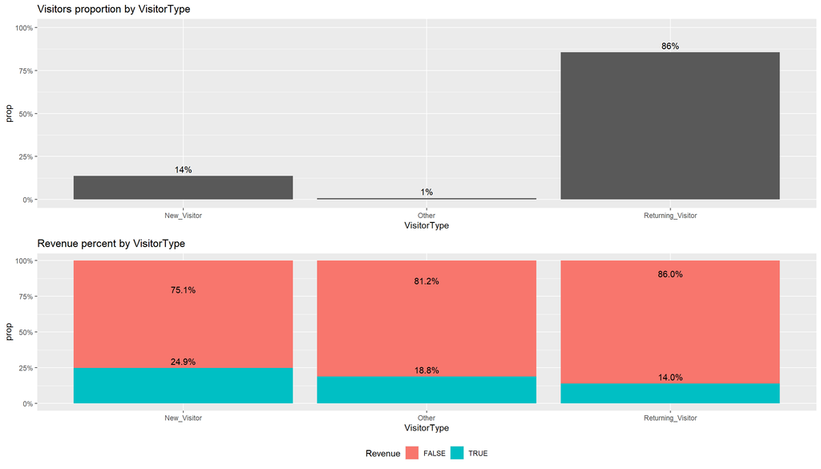

```r
plot_var_Revenue<- function(x){
    group<- df %>% group_by(df[,x], Revenue) %>% summarize(n = n()) %>%
        mutate(prop = n/sum(n)) %>% rename(var = "df[, x]")

    g0<-ggplot(group,aes(x = var, y = prop, fill = Revenue)) +
        geom_col() +
        geom_text(aes(label = percent(prop)), vjust = -0.5) +
        scale_y_continuous(labels = scales::percent) +
        labs(x = x,
             title = paste("Revenue percent by",x)) +
        theme(legend.position="bottom")

    prop_count<- df %>% group_by(df[,x]) %>% summarize(n = n()) %>%
        mutate(prop = n/sum(n)) %>% rename(var = "df[, x]")

    g1<-ggplot(prop_count, aes(x = var, y=prop)) +
        geom_col() +
        geom_text(aes(label = percent(prop)), vjust = -0.5) +
            scale_y_continuous(labels = scales::percent) +
                labs(x = x,
                 title = paste("Visitors proportion by", x) ) +
        expand_limits(y = seq(0,1, by = .1))


    grid.arrange(g1, g0, nrow = 2, ncol =1)
}
cat_vars<- df %>% select_if(is.factor) %>% colnames()

for (var in cat_vars){
  print(var)
  plot_var_Revenue(var)
}
```

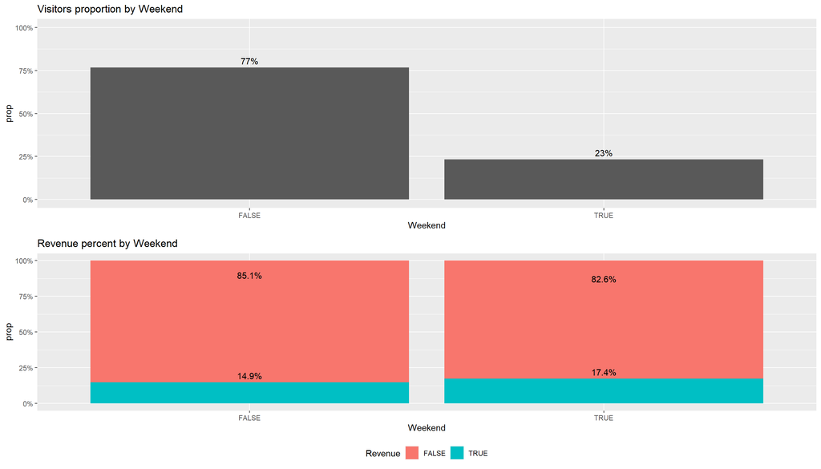

```r
plot_var_Revenue("Weekend")
```

- if we analyze in more depth the variable month, we can realize a couple of things

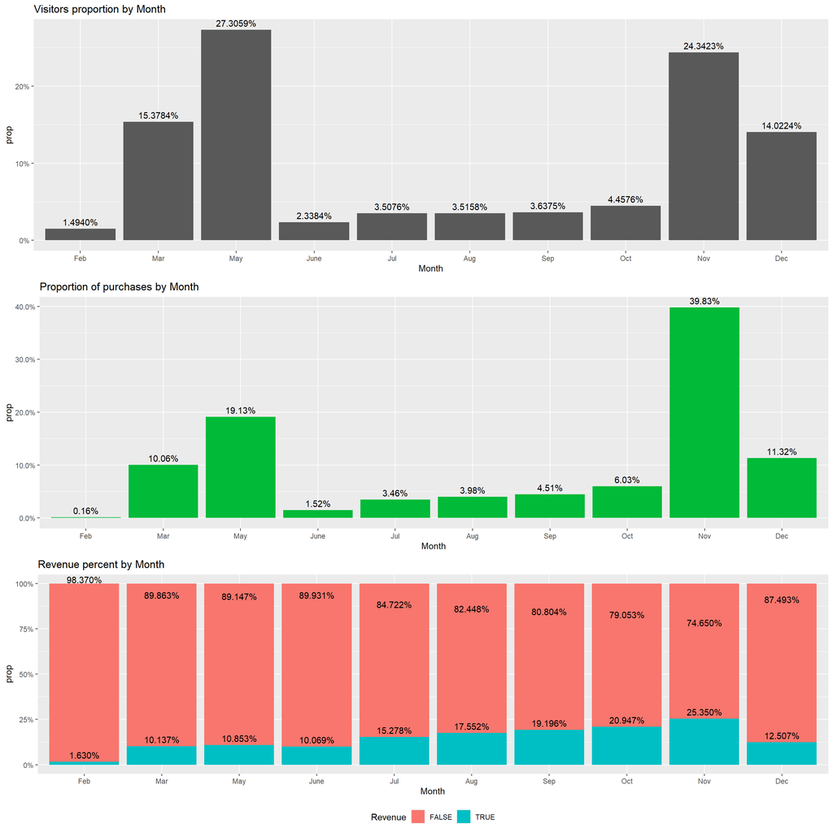

```r
prop_count_revenue_T<- df %>%filter(Revenue == T) %>%group_by(Month) %>% summarize(n = n()) %>%
  mutate(prop = n/sum(n))


prop_count<- df %>% group_by(Month) %>% summarize(n = n()) %>%
  mutate(prop = n/sum(n))

count_sales_corr<- cor.test(prop_count_revenue_T$prop, prop_count$prop)


plot_month_Revenue<- function(x){
  group<- df %>% group_by(df[,x], Revenue) %>% summarize(n = n()) %>%
    mutate(prop = n/sum(n)) %>% rename(var = "df[, x]")

  g0<-ggplot(group,aes(x = var, y = prop, fill = Revenue)) +
    geom_col() +
    geom_text(aes(label = percent(prop)), vjust = -0.5) +
    scale_y_continuous(labels = scales::percent) +
    labs(x = x,
         title = paste("Revenue percent by",x)) +
    theme(legend.position="bottom")

  prop_count<- df %>% group_by(df[,x]) %>% summarize(n = n()) %>%
    mutate(prop = n/sum(n)) %>% rename(var = "df[, x]")

  g1<-ggplot(prop_count, aes(x = var, y=prop)) +
    geom_col() +
    geom_text(aes(label = percent(prop)), vjust = -0.5) +
    scale_y_continuous(labels = scales::percent) +
    labs(x = x,
         title = paste("Visitors proportion by", x) )

  prop_count_revenue_T<- df %>%filter(Revenue == T) %>%group_by(Month) %>% summarize(n = n()) %>%
    mutate(prop = n/sum(n))

  g2<- ggplot(prop_count_revenue_T, aes(x = Month, y=prop)) +
    geom_col(fill = "#00BA38") +
    geom_text(aes(label = percent(prop)), vjust = -0.5) +
    scale_y_continuous(labels = scales::percent) +
    labs(x = x,
         title = paste("Proportion of purchases by Month"))

  grid.arrange(g1, g2, g0, nrow = 3, ncol =1)
}

plot_month_Revenue("Month")
```

- We can observe a relationship between the number of visitors and the number of sales, the result of the correlation test, correlation on average is **0.85** with a 95% confidence interval **[0.48 , 0.96]**

```r
df_prop<-data.frame(prop_count_revenue_T$prop,prop_count$prop)
names(df_prop) <- c("prop_revenue_T", "prop_count")
df_prop<- cbind(levels(df$Month),df_prop) %>% rename(Month = "levels(df$Month)")

mode_lm<-lm(prop_revenue_T~prop_count, data = df_prop)
summary(mode_lm)
```

```
##
## Call:
## lm(formula = prop_revenue_T ~ prop_count, data = df_prop)
##
## Residuals:
##       Min        1Q    Median        3Q       Max
## -0.090427 -0.024050 -0.000791  0.010894  0.147717
##
## Coefficients:
##              Estimate Std. Error t value Pr(>|t|)
## (Intercept) -0.005008   0.030818  -0.163  0.87494
## prop_count   1.050081   0.227395   4.618  0.00171 **
## ---
## Signif. codes:  0 '***' 0.001 '**' 0.01 '*' 0.05 '.' 0.1 ' ' 1
##
## Residual standard error: 0.06578 on 8 degrees of freedom
## Multiple R-squared:  0.7272, Adjusted R-squared:  0.6931
## F-statistic: 21.32 on 1 and 8 DF,  p-value: 0.001715
```

```r
df_lm<- augment(mode_lm, df_prop)
df_lm %>% select(Month:.fitted, .resid)
```

```
## # A tibble: 10 x 5
##    Month prop_revenue_T prop_count .fitted   .resid
##    <chr>          <dbl>      <dbl>   <dbl>    <dbl>
##  1 Feb          0.00157     0.0149  0.0107 -0.00911
##  2 Mar          0.101       0.154   0.156  -0.0558
##  3 May          0.191       0.273   0.282  -0.0904
##  4 June         0.0152      0.0234  0.0195 -0.00435
##  5 Jul          0.0346      0.0351  0.0318  0.00277
##  6 Aug          0.0398      0.0352  0.0319  0.00792
##  7 Sep          0.0451      0.0364  0.0332  0.0119
##  8 Oct          0.0603      0.0446  0.0418  0.0185
##  9 Nov          0.398       0.243   0.251   0.148
## 10 Dec          0.113       0.140   0.142  -0.0290
```

- June and July are the months in which we can expect our prediction to be most accurate. Now we can answer the question: What proportion of sales can we obtain if we manage to increase the proportion of visits by 5% in June or July?

```r
pred_months<- df_lm %>% select(Month:prop_count) %>% filter(Month %in% c("June", "Jul"))
prop_count_fixed <- c( pred_months$prop_count + 0.05)
pred_prop_revenue<-predict(mode_lm, newdata = list(prop_count = pred_months$prop_count + 0.05))
improvement<- pred_prop_revenue - pred_months$prop_revenue_T
results<- tibble(cbind(pred_months, prop_count_fixed, pred_prop_revenue,improvement))
results
```

```
## # A tibble: 2 x 6
##   Month prop_revenue_T prop_count prop_count_fixed pred_prop_revenue improvement
##   <chr>          <dbl>      <dbl>            <dbl>             <dbl>       <dbl>
## 1 June          0.0152     0.0234           0.0734            0.0721      0.0569
## 2 Jul           0.0346     0.0351           0.0851            0.0843      0.0497
```

- If we manage to increase June or July visits by **5%**, we can expect to see an improvement of **5.69%** and **4.97%** respectively

### Numerical variables

```
## [1] "Administrative"
```

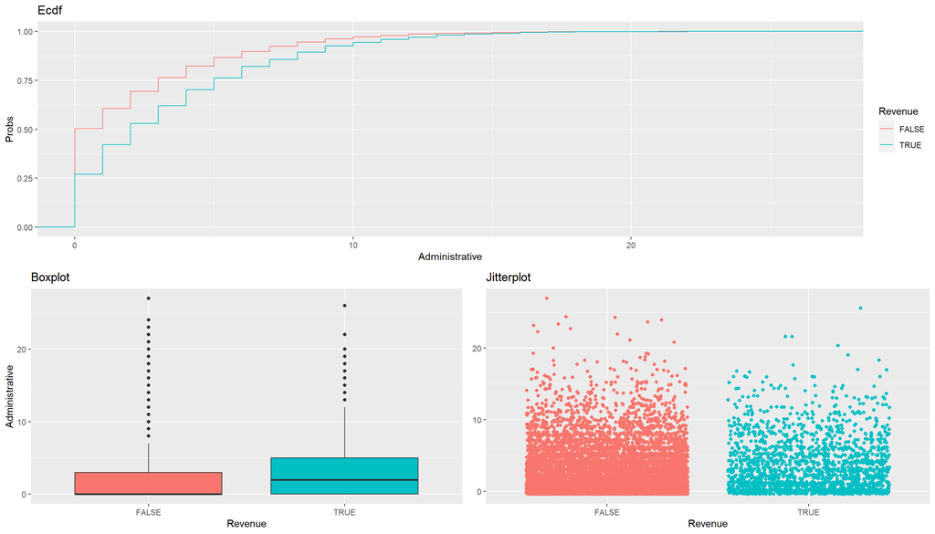

```
## [1] "Administrative_Duration"
```

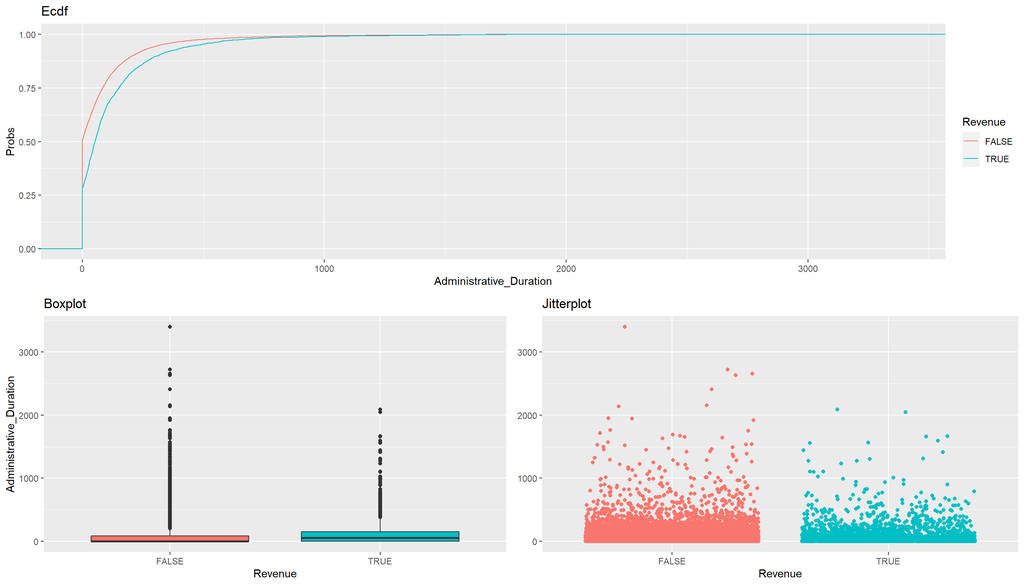

```
## [1] "Informational"
```

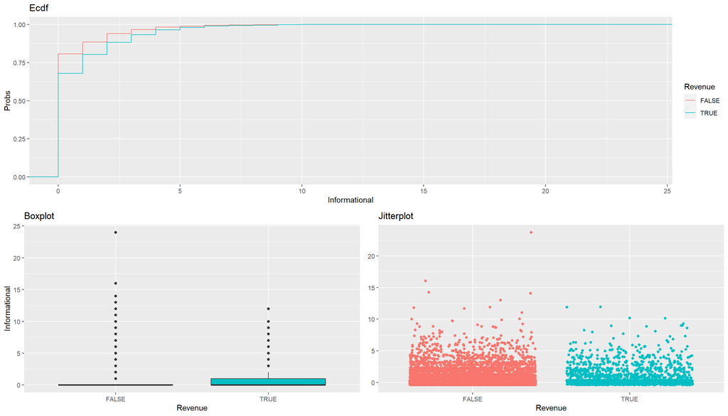

```
## [1] "Informational_Duration"
```

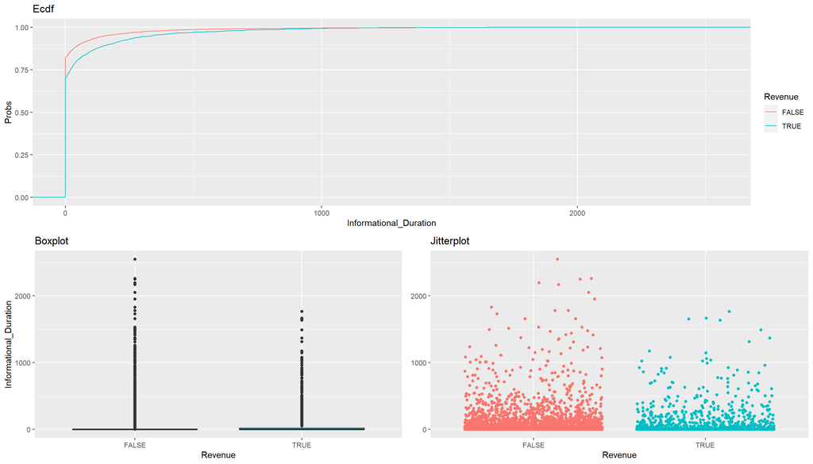

```
## [1] "ProductRelated"
```

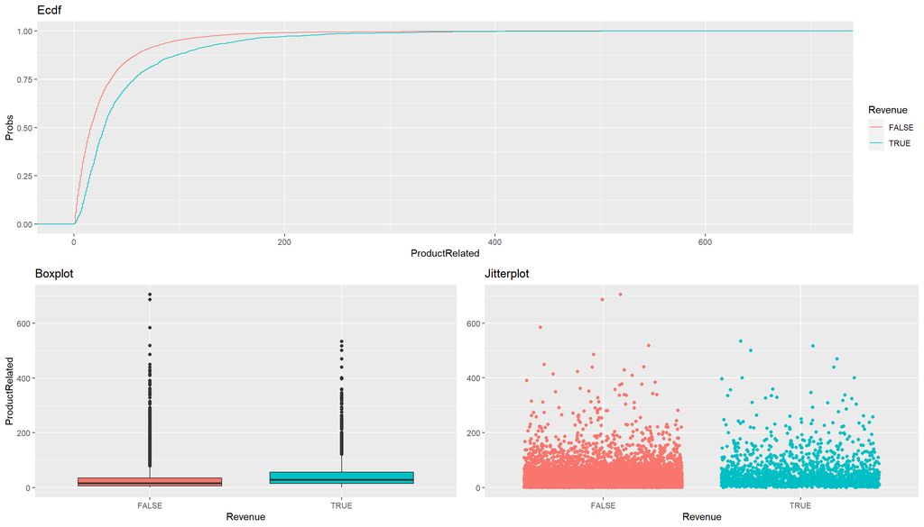

```
## [1] "ProductRelated_Duration"
```

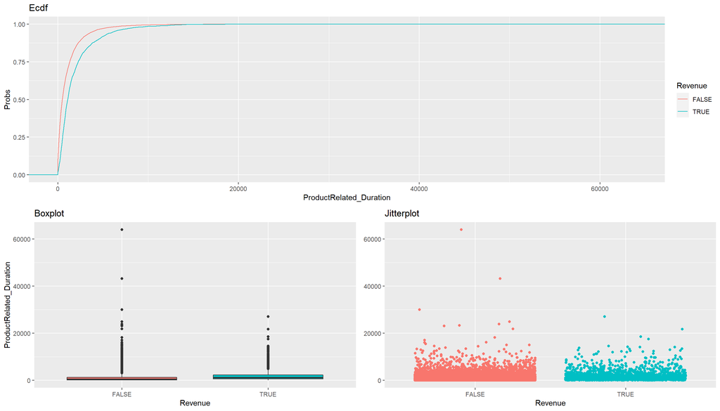

```
## [1] "BounceRates"
```

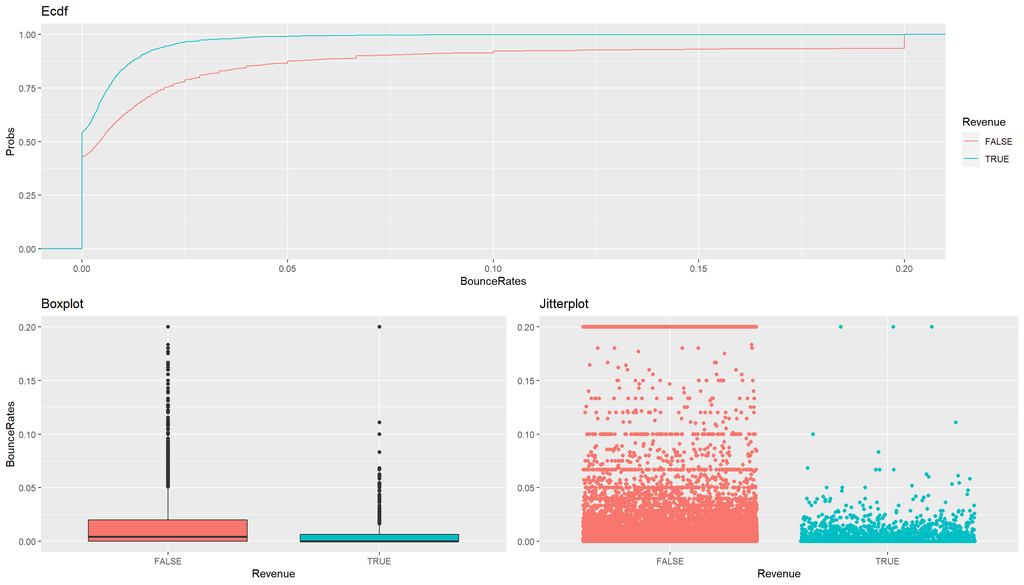

```
## [1] "ExitRates"
```

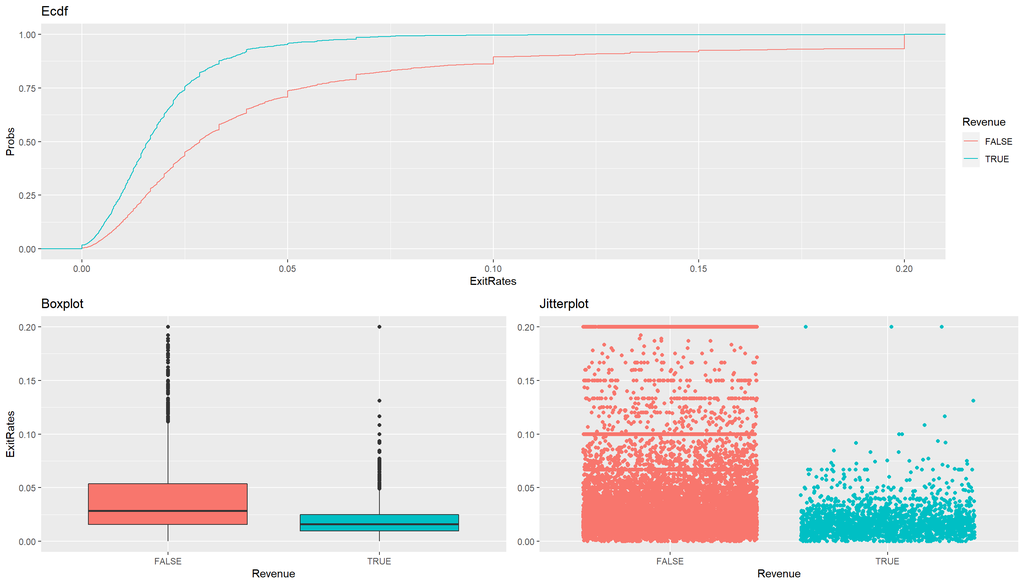

```
## [1] "PageValues"
```

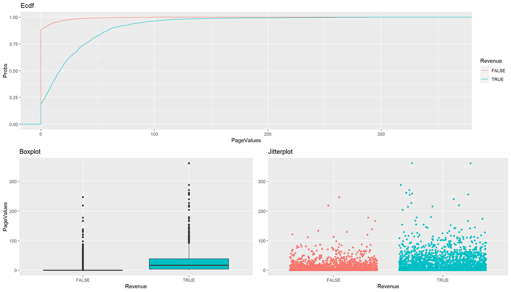

```
## [1] "TrafficType"
```

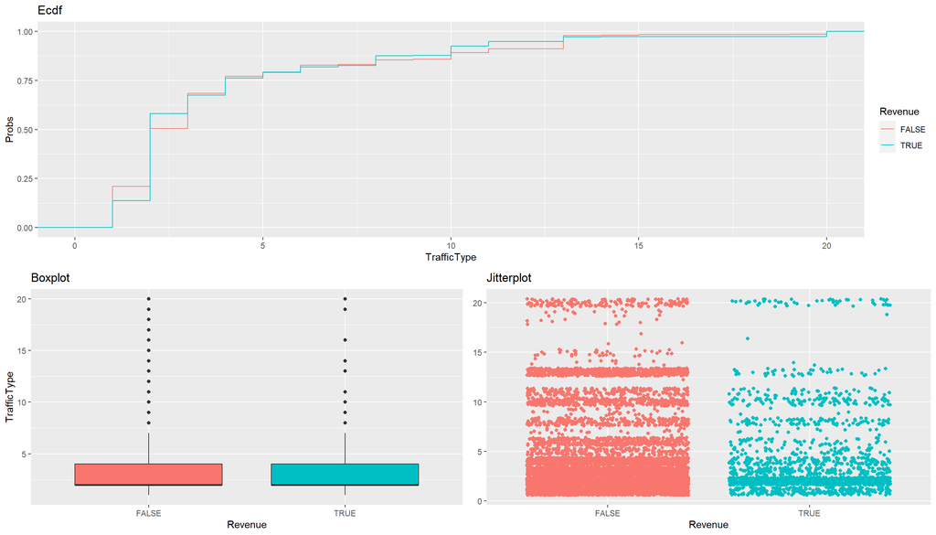

```r
for (var in colnames(num_vars)){
    print(var)
    jit<- ggplot(df,aes(x = Revenue, y = df[,var])) +
            geom_jitter(aes(color = Revenue),show.legend = F) +
              labs(y = var,
                   title = "Jitterplot") +
                theme(axis.title.y = element_blank())

    box<- ggplot(df,aes(x = Revenue, y = df[,var])) +
            geom_boxplot(aes(fill = Revenue),show.legend = F) +
                labs(y = var,
                     title = "Boxplot")
    ecdf<- ggplot(df,aes(df[,var])) +
            stat_ecdf(aes(color = Revenue)) +
                labs(x = var,
                     y = "Probs",
                     title = "Ecdf") +
                expand_limits(x = seq(0, max(df[,var]), by = 1))

    grid.arrange(ecdf,arrangeGrob( box, jit ,ncol = 2), nrow = 2)
}
```

# Machine Learning

## Introduction

- I am going to apply machine learning classification algorithms that are part of supervised learning, in other words, a field is required which has labels to be able to train the algorithm, our field will be Revenue, since we want to predict when a customer makes a purchase.
- As we have already seen, Revenue can be False or True, we are interested in predicting as accurately as possible when this value will be True.
- I have used the H2o API to run different models, the Caret package to implement and optimize the XGBoost algorithm and the Lares library that allows using the H2O API and facilitates the use of some graphics to understand the commercial value of the algorithm.

## Techniques used

- I have used 3 techniques to avoid overtraining
  - Train/Test split.
  - Stratified cross validation.
  - Early stop (for boosting based algorithms).
- The algorithms are evaluated with 3 metrics
  - **AUC** (area under the curve) If we obtain a perfect classifier, then the AUC score is 1.0. If the classifier is random in its guesses, then the AUC score is 0.5.
  - **LogLoss** it is a measure of uncertainty (you may call it entropy), so a low Log Loss means a low uncertainty/entropy of your model. Log Loss is similar to the Accuracy, but it will favor models that distinguish more strongly the classes.
  - **Error class 1** it is the proportion of error of the algorithm with respect to class 1 (Revenue = True), in technical vocabulary **1 - recall**.

## H2o

### H2o connection

```r
h2o.init(
    ip = "localhost",
    nthreads = -1,
    max_mem_size = "4g"
)
```

[output not shown]

### Data preparation for H2o

```r
df1<- df
df1$Month <- as.character(df1$Month) # H2O don't allows Ordered factors
df_h2o<- as.h2o(df1)
df_h2o$Month <- h2o.asfactor(df_h2o$Month)
h2o.describe(df_h2o)
```

```
##                      Label Type Missing Zeros PosInf NegInf Min        Max
## 1           Administrative  int       0  5754      0      0   0    27.0000
## 2  Administrative_Duration real       0  5857      0      0  -1  3398.7500
## 3            Informational  int       0  9686      0      0   0    24.0000
## 4   Informational_Duration real       0  9879      0      0  -1  2549.3750
## 5           ProductRelated  int       0    35      0      0   0   705.0000
## 6  ProductRelated_Duration real       0   719      0      0  -1 63973.5222
## 7              BounceRates real       0  5510      0      0   0     0.2000
## 8                ExitRates real       0    76      0      0   0     0.2000
## 9               PageValues real       0  9586      0      0   0   361.7637
## 10              SpecialDay enum       0 11065      0      0   0     5.0000
## 11                   Month enum       0   433      0      0   0     9.0000
## 12        OperatingSystems enum       0  2582      0      0   0     7.0000
## 13                 Browser enum       0  2459      0      0   0    12.0000
## 14                  Region enum       0  4774      0      0   0     8.0000
```

[output cut: 23 more lines]

```r
#--------------------------------Train/Test split-----------------------------------------------

particiones <- h2o.splitFrame(data = df_h2o, ratios = c(0.8), seed = 33)
train <- h2o.assign(data = particiones[[1]], key = "train")
test <- h2o.assign(data = particiones[[2]], key = "test")

train$Revenue <- h2o.asfactor(train$Revenue)
test$Revenue <- h2o.asfactor(test$Revenue)

y <- "Revenue"
x <-setdiff(h2o.colnames(df_h2o),y)

h2o.table(train$Revenue)/h2o.nrow(train$Revenue)
```

```
##   Revenue     Count
## 1     NaN 0.8434879
## 2     NaN 0.1565121
##
## [2 rows x 2 columns]
```

```r
h2o.table(test$Revenue)/h2o.nrow(test$Revenue)
```

```
##   Revenue     Count
## 1     NaN 0.8515916
## 2     NaN 0.1484084
##
## [2 rows x 2 columns]
```

- Really unbalanced classes, this problem will be solved by adjust some arguments in the model construction.

### Data preparation for XGBoost

```r
df$Month <- as.numeric(df$Month)
df1<-df
#-------Transform all categorical variables to factor, to allows us convert it to dummies variables
for (col in colnames(df1)){
    if (n_distinct(df1[[col]]) > 2 & n_distinct(df1[[col]]) < 21){
        df1[[col]] <- factor(df1[[col]])
    }
}

df1<- dummy.data.frame(df1, dummy.classes = "factor")
for (col in colnames(df1)){
    if (class(df1[[col]]) == "factor"){
        df1[[col]] <- as.numeric(df1[[col]])
    }
}
#------------------Train/Test split----------------------------
set.seed(33)
validation_index<-createDataPartition(df1$Revenue, p=0.8, list=FALSE)
testSet<-df1[-validation_index,]
trainSet<-df1[validation_index,]
```

## Models

### H2O

```r
model_glm <- h2o.glm(
    y= y, x= x, training_frame= train,validation_frame = test,
    family= "binomial", link= "logit",
    standardize= T, balance_classes= T,
    lambda_search= T,
    solver= "AUTO", alpha= 0.95,
    seed= 33,
    nfolds= 5, fold_assignment = "Stratified",
    model_id = "model_glm"
)

model_dp <- h2o.deeplearning( y= y, x= x, training_frame= train,validation_frame = test,
                              balance_classes = TRUE, standardize = TRUE,
                              activation = "Tanh", epochs = 1000, epsilon = 0.0003,
                              loss = "CrossEntropy",input_dropout_ratio = 0.3,
                              stopping_rounds = 5, stopping_metric = "logloss",
                              categorical_encoding = "Binary", verbose = T, model_id = "model_dp")


auto_ML<- h2o.automl(x= x, y= y,training_frame = train, validation_frame = test,
                     nfolds = 5, balance_classes = T)
```

### XGBoost with Grid Search

- We will run 2160 models to get the best hyperparameters(432 combinations with kfolds = 5).

```r
param <- expand.grid(nrounds = c(50,100),
                      max_depth = c(5, 6, 10, 12),
                      eta = c(0.3, 0.1, 0.03), gamma = c(0.5, 1),
                      colsample_bytree = c(0.8, 0.9, 1), min_child_weight = 1,
                      subsample = c(0.5,0.8, 1))
set.seed(33)
xgb_trcontrol = trainControl(
    method = "cv",
    number = 5,
    verboseIter = TRUE,
    returnData = FALSE,
    returnResamp = "all",              # save losses across all models
    classProbs = TRUE,                 # set to TRUE for LogLoss to be computed
    allowParallel = TRUE,
    summaryFunction = mnLogLoss,
    preProcOptions = "scale")          #scale numeric variables

set.seed(33)
fit.xgb <- train(x = as.matrix(select(trainSet,-Revenue)),
                 y = factor(trainSet$Revenue, labels = c("first_class", "second_class")),
                 method="xgbTree",
                 metric="logLoss", trControl=xgb_trcontrol ,tuneGrid=param)
```

## Model Evaluation

```r
eval <- predict(fit.xgb, testSet,type = "prob")[["second_class"]] > 0.5

confusion_matrix_xgb0 <- cbind(testSet$Revenue, eval) %>%
    data.frame() %>%
    table() %>% confusionMatrix()

models <- c("Stacked Ensemble auto", "GBM0 auto","GBM1 auto","GLM","Deep Learning","XGB")

error_class_1 <- round(c(h2o.confusionMatrix(model1, valid=T)[,3][2],
                  h2o.confusionMatrix(model2, valid=T)[,3][2],
                  h2o.confusionMatrix(model3, valid=T)[,3][2],
                  h2o.confusionMatrix(model_glm, valid=T)[,3][2],
                  h2o.confusionMatrix(model_dp, valid=T)[,3][2],
                  confusion_matrix_xgb0$table[2,1] /
                      (confusion_matrix_xgb0$table[2,1] + confusion_matrix_xgb0$table[2,2])),4)

logloss_ <- round(c(h2o.logloss(h2o.performance(model1, valid = T)),
              h2o.logloss(h2o.performance(model2, valid = T)),
              h2o.logloss(h2o.performance(model3, valid = T)),
              h2o.logloss(h2o.performance(model_glm, valid = T)),
              h2o.logloss(h2o.performance(model_dp, valid = T)),
              logLoss(testSet$Revenue, predict(fit.xgb, testSet,type = "prob")[["second_class"]])),4)

auc_ <- round(c(h2o.auc(h2o.performance(model1, valid = T)),
          h2o.auc(h2o.performance(model2, valid = T)),
          h2o.auc(h2o.performance(model3, valid = T)),
          h2o.auc(h2o.performance(model_glm, valid = T)),
          h2o.auc(h2o.performance(model_dp, valid = T)),
          auc(testSet$Revenue, predict(fit.xgb, testSet,type = "prob")[["second_class"]])),4)


eval_models <- data.frame(models, auc_, logloss_, error_class_1, stringsAsFactors = F) %>%
    arrange(desc(auc_))
eval_models
```

```
##                  models   auc_ logloss_ error_class_1
## 1                   XGB 0.9562   0.1880        0.3701
## 2 Stacked Ensemble auto 0.9284   0.2493        0.3203
## 3             GBM0 auto 0.9280   0.2306        0.2423
## 4             GBM1 auto 0.9269   0.2323        0.3120
## 5                   GLM 0.8795   0.2937        0.3900
## 6         Deep Learning 0.8401   3.8847        0.3148
```

- The table is sorted in descending order by auc_, the models with “auto” termination are created automatically with h2o. The winning model is XGBoost, it should be noted that with a manual configuration of hyperparameters was already the best, but also made a search for the best hyperparameters using Grid Search.
- Next I try h2o with the Lares library that allows us to configure some more parameters, I will select the best model and compare it with XGBoost

```r
lares_auto<-h2o_automl(df1, y = "Revenue", target = "TRUE" , split = 0.8, balance = TRUE, scale = TRUE, max_models = 10, exclude_algos = NULL, project ="Online shoppers intentions", seed = 33,
                       stopping_metric = "AUC", stopping_rounds = 5, no_outliers = F)
```

```
## 2021-01-07 09:20:31 | Started process...
```

```
## - INDEPENDENT VARIABLE: Revenue
```

```
## - MODEL TYPE: Classification
```

```
## # A tibble: 2 x 5
##   tag       n     p order  pcum
##   <lgl> <int> <dbl> <int> <dbl>
## 1 FALSE 10408  84.5     1  84.5
## 2 TRUE   1908  15.5     2 100
```

```
## - MISSINGS: No missing values in your data
```

```
## - CATEGORICALS: There are 1 non-numerical features. Consider using ohse() or equivalent prior to encode categorical variables.
```

```
## - TRANSFORMATIONS: All numerical features (94) were scaled
```

```
## >>> Splitting datasets...
```

```
## train_size  test_size
##       9852       2464
```

```
## - REPEATED: There were 82 repeated rows which are being suppressed for the train dataset
```

```
## - BALANCE: Training set balanced: 1505 observations for each (2) category; using 30.81% of training data
```

```
## - CACHE: Previous models are not being erased. You may use 'start_clean' [clear] or 'project_name' [join]
```

```
## >>> Iterating until 10 models or 600 seconds...
```

```
##
## 09:20:34.773: AutoML: XGBoost is not available; skipping it.
```

```
## - EUREKA: Succesfully generated 12 models
```

```
##                                           model_id       auc   logloss
## 1                     GBM_2_AutoML_20210107_092034 0.9316932 0.2274132
## 2                     GBM_3_AutoML_20210107_092034 0.9296409 0.2297597
## 3 StackedEnsemble_AllModels_AutoML_20210107_092034 0.9294944 0.2417116
##       aucpr mean_per_class_error      rmse        mse
## 1 0.7421809            0.1737821 0.2632354 0.06929289
## 2 0.7405798            0.1756280 0.2647643 0.07010012
## 3 0.7412639            0.1772569 0.2665581 0.07105324
```

```
## - UI: Check results using H2O Flow's interface: http://localhost:54321/flow/index.html
```

```
## SELECTED MODEL: GBM_2_AutoML_20210107_092034
```

```
## - NOTE: The following variables were the least important: "TrafficType8", "Browser2", "TrafficType4", "Region2", "TrafficType1", "TrafficType5", "Browser1", "Browser4" and 64 other...
```

```
## >>> Running predictions for Revenue...
```

```
## Target value: TRUE
```

```
## ROC Curve Plot rendered with sampled data...
```

```
## >>> Generating plots...
```

```
## ROC Curve Plot rendered with sampled data...
```

```
## Model (1/12): GBM_2_AutoML_20210107_092034
## Independent Variable: Revenue
## Type: Classification (2 classes)
## Algorithm: GBM
## Split: 80% training data (of 12316 observations)
## Seed: 33
##
## Test metrics:
## "   AUC = 0.93548"
## "   ACC = 0.097403"
## "   PRC = 0.072736"
## "   TPR = 0.38462"
## "   TNR = 0.041242"
##
## Most important variables:
## "   PageValues (60.4%)"
## "   BounceRates (5.4%)"
## "   ProductRelated (5.3%)"
## "   ExitRates (4.4%)"
## "   ProductRelated_Duration (4.1%)"
```

```
## Process duration: 2.57m
```

```r
#---------------------------------------Evaluation best models-------------------------------------
best_models <- c("GBM","XGBoost")

error_class_1 <- round(c(h2o.confusionMatrix(lares_auto$model,)[,3][2],
                   confusion_matrix_xgb0$table[2,1] /
                       (confusion_matrix_xgb0$table[2,1] + confusion_matrix_xgb0$table[2,2])),4)

logloss_ <- round(c(h2o.logloss(h2o.performance(lares_auto$model, xval = T)),
            logLoss(testSet$Revenue, predict(fit.xgb, testSet,type = "prob")[["second_class"]])),4)

auc_ <- round(c(h2o.auc(h2o.performance(lares_auto$model, xval = T)),
        auc(testSet$Revenue, predict(fit.xgb, testSet,type = "prob")[["second_class"]])),4)

eval_best_models <- data.frame(best_models, auc_, logloss_, error_class_1) %>% arrange(desc(auc_))
eval_best_models
```

```
##   best_models   auc_ logloss_ error_class_1
## 1     XGBoost 0.9562   0.1880        0.3701
## 2         GBM 0.9317   0.2274        0.1980
```